# Analyzing Baywheels Trip Data

## by JD Pritchett

## Investigation Overview

> The goal of this analysis is to identify trends in among users of a bike rental service in San Francisco. The main factors considered in this project were the distance traveled, the duration of the trip, the start day and time, and the different types bikes and users that rented these bikes.

## Dataset Overview

> The original dataset consisted of 154,967 different user trips in July of 2020 and was trimmed to 75,921 different user trips after cleaning. The start day and month variables were extracted from the original timestamp data and were converted to categorical variables. The different types of bikes and users were two other categorical variables used. The only two numeric variables analyzed were the duration and distance variables.

```python
# load in the dataset into a pandas dataframe

df_clean = pd.read_csv('df_clean.csv')
```

## Distribution of Start Day and Start Time

> Here we can see that most of the trips occurred between on Wednesdays, Thursdays, Fridays, or Saturdays, and most of the trips started between noon and 7 PM.

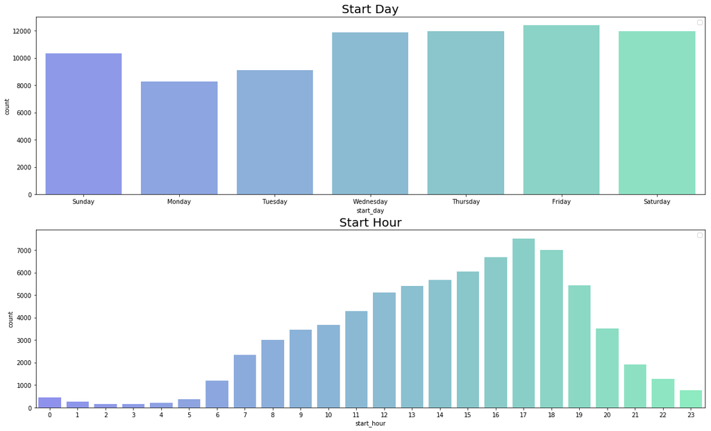

```python
import logging
logging.getLogger().setLevel(logging.CRITICAL)

plt.figure(figsize = [20, 12]);

# subplot 1: start day
ax = plt.subplot(2, 1, 1);
sb.countplot(data = df_clean, x = 'start_day', palette = 'winter', alpha = .5)
ax.legend(loc = 0, ncol = 2); # re-arrange legend to remove overlapping
ax.set_title('Start Day', fontsize = 20);

# subplot 4: start hour
ax = plt.subplot(2, 1, 2);
sb.countplot(data = df_clean, x = 'start_hour', palette = 'winter', alpha = .5);
ax.legend(loc = 0, ncol = 3); # re-arrange legend to remove overlapping
ax.set_title('Start Hour', fontsize = 20);

plt.show();
```

## Correlation Between Distance and Duration

> You might think that the longer people ride their bikes, the further they go, but the data told a different story. While these two variables were positively correlated, their correlation was a weak one as seen below.

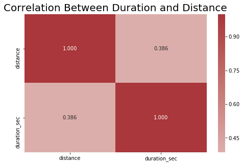

```python
numeric_vars = ['distance', 'duration_sec']
plt.figure(figsize = [8, 5])
sb.heatmap(df_clean[numeric_vars].corr(), annot = True, fmt = '.3f',
           cmap = 'vlag', center = 0)
plt.title('Correlation Between Duration and Distance', fontsize = 20)
plt.show()
```

## Hourly Usage During Weekdays for Customers and Subscribers

> Here we take a deeper look at the difference between when casual users and subscribers start their trips. We can see that casual users started their ride around 2 PM on Saturdays the most, and members started their rides around 5-6 PM on Wednesdays the most.

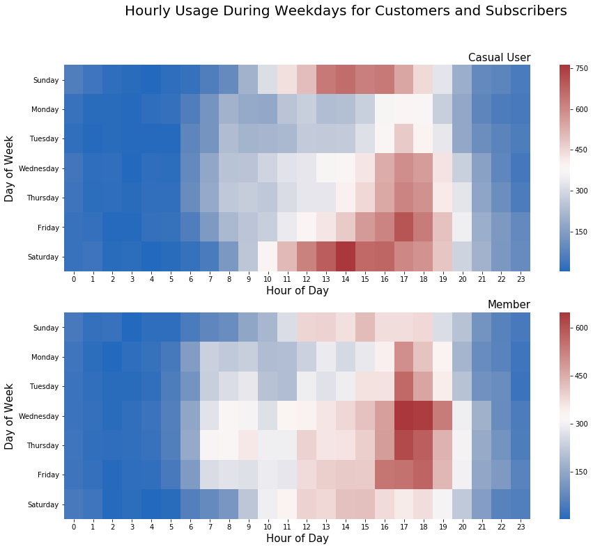

```python
plt.figure(figsize = [15,12])

plt.suptitle('Hourly Usage During Weekdays for Customers and Subscribers', fontsize = 20)

plt.subplot(2, 1, 1)
customers = df_clean.query('member_casual == "casual"')
ct_counts = customers.groupby(['start_day', 'start_hour']).size()
ct_counts = ct_counts.reset_index(name='count')
ct_counts = ct_counts.pivot(index='start_day', columns='start_hour', values='count')
sb.heatmap(ct_counts, cmap='vlag');
plt.title('Casual User', loc='right', fontsize = 15);
plt.xlabel('Hour of Day', fontsize = 15);
plt.ylabel('Day of Week', fontsize = 15);

plt.subplot(2, 1, 2)
subscribers = df_clean.query('member_casual == "member"')
st_counts = subscribers.groupby(['start_day', 'start_hour']).size()
st_counts = st_counts.reset_index(name='count')
st_counts = st_counts.pivot(index='start_day', columns='start_hour', values='count')
sb.heatmap(st_counts, cmap='vlag');
plt.title('Member', loc='right', fontsize = 15);
plt.xlabel('Hour of Day', fontsize = 15);
plt.ylabel('Day of Week', fontsize = 15);
```